# Problem set 3

Yonatan Schoen

2023-05-28

# ML for economics - Problem Set 3

### Packages install

```r
if (!require("pacman")) install.packages("pacman")
pacman::p_load(
  tidyverse,
  broom,
  rpart,
  rpart.plot,
  ranger,
  rsample,
  vip,
  knitr,
  here,
  rattle,
  magrittr,
  tidymodels,
  caret,
  DALEX,
  RColorBrewer,
  ada,
  doParallel,
  pROC,
  tinytex
)
```

```
##
##  C:\Users\yonat\AppData\Local\Temp\RtmpA91nst\downloaded_packages
```

### Question 1 - data load and code chunk

```r
# load data heart and change the outcome var to factor (it is numeric at first)
hearts <- data("heart.csv") %>%
  read_csv()  %>%
  mutate(target = as_factor(target))
set.seed(167)

# Question 1 - run code
formula_part <- target ~ sex + cp + chol
formula_full <- target ~ .
```

### Question 2 - fit the model

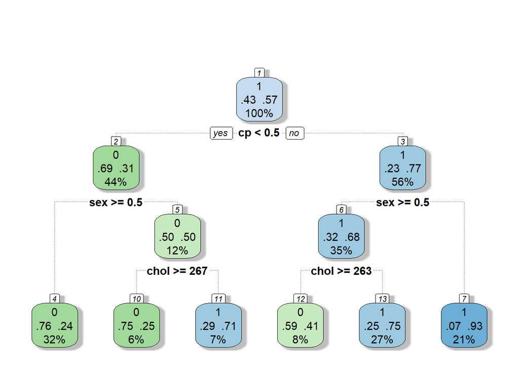

```r
# first we split to train
hearts_split <- hearts %>%
                initial_split(prop = 0.7)

heart_train <- training(hearts_split)
heart_test <- testing(hearts_split)

# now we fit the model
tree_fit <- rpart(formula = formula_part,
                  data = heart_train,
                  method = "class")


fancyRpartPlot(tree_fit, caption = NULL)
```

### Question 3

```r
tree_fit1 <- rpart(
  formula = formula_full,
  data = heart_train,
  method = "class",
  control = rpart.control(
    minsplit = 2, minbucket = 1
    )
  )

tree_fit2 <- rpart(
  formula = formula_full,
  data = heart_train,
  method = "class"
  )


printcp(tree_fit1)
```

```
##
## Classification tree:
## rpart(formula = formula_full, data = heart_train, method = "class",
##     control = rpart.control(minsplit = 2, minbucket = 1))
##
## Variables actually used in tree construction:
## [1] age      ca       chol     cp       oldpeak  restecg  thal     thalach
## [9] trestbps
##
## Root node error: 92/212 = 0.43396
##
## n= 212
##
##         CP nsplit rel error  xerror     xstd
## 1 0.434783      0  1.000000 1.00000 0.078438
## 2 0.065217      1  0.565217 0.77174 0.074694
## 3 0.038043      3  0.434783 0.59783 0.069371
## 4 0.032609      5  0.358696 0.61957 0.070169
## 5 0.021739      6  0.326087 0.61957 0.070169
## 6 0.014493     10  0.239130 0.61957 0.070169
## 7 0.010870     13  0.195652 0.63043 0.070554
## 8 0.010000     22  0.097826 0.68478 0.072328
```

```r
printcp(tree_fit2)
```

```
##
## Classification tree:
## rpart(formula = formula_full, data = heart_train, method = "class")
##
## Variables actually used in tree construction:
## [1] ca      cp      oldpeak thal    thalach
##
## Root node error: 92/212 = 0.43396
##
## n= 212
##
##         CP nsplit rel error  xerror     xstd
## 1 0.434783      0   1.00000 1.00000 0.078438
## 2 0.065217      1   0.56522 0.70652 0.072973
## 3 0.038043      3   0.43478 0.55435 0.067646
## 4 0.032609      5   0.35870 0.50000 0.065234
## 5 0.010000      6   0.32609 0.51087 0.065741
```

As can be seen, there is 9 variables in the fully grown restricted model and 5 in the unrestricted one.

### Question 4 - Predict the model

```r
# For more elegant code I'll insert the prediction and data binding in function
pred_func <- function(model, data) {
  model %>%
  predict(type = "class", newdata = data) %>%
  as_tibble() %>%
  bind_cols(data) %>%
  select(target, value) %>%
  rename("pred" = "value") %>%
    mutate()
}

# Predict the training set
insample1 <- pred_func(model = tree_fit1, data = heart_train)
insample2 <- pred_func(model = tree_fit2, data = heart_train)

# Predict the test set
outsample1 <- pred_func(model = tree_fit1, data = heart_test)
outsample2 <- pred_func(model = tree_fit2, data = heart_test)

#confusion matrix
confusionMatrix(insample1$target, insample1$pred)
```

```
## Confusion Matrix and Statistics
##
##           Reference
## Prediction   0   1
##          0  85   7
##          1   2 118
##
##                Accuracy : 0.9575
##                  95% CI : (0.9209, 0.9804)
##     No Information Rate : 0.5896
##     P-Value [Acc > NIR] : <2e-16
##
##                   Kappa : 0.913
##
##  Mcnemar's Test P-Value : 0.1824
##
##             Sensitivity : 0.9770
##             Specificity : 0.9440
##          Pos Pred Value : 0.9239
##          Neg Pred Value : 0.9833
##              Prevalence : 0.4104
##          Detection Rate : 0.4009
##    Detection Prevalence : 0.4340
##       Balanced Accuracy : 0.9605
##
##        'Positive' Class : 0
##
```

```r
confusionMatrix(insample2$target, insample2$pred)
```

```
## Confusion Matrix and Statistics
##
##           Reference
## Prediction   0   1
##          0  71  21
##          1   9 111
##
##                Accuracy : 0.8585
##                  95% CI : (0.8042, 0.9024)
##     No Information Rate : 0.6226
##     P-Value [Acc > NIR] : 2.627e-14
##
##                   Kappa : 0.7075
##
##  Mcnemar's Test P-Value : 0.04461
##
##             Sensitivity : 0.8875
##             Specificity : 0.8409
##          Pos Pred Value : 0.7717
##          Neg Pred Value : 0.9250
##              Prevalence : 0.3774
##          Detection Rate : 0.3349
##    Detection Prevalence : 0.4340
##       Balanced Accuracy : 0.8642
##
##        'Positive' Class : 0
##
```

```r
confusionMatrix(outsample1$target, outsample1$pred)
```

```
## Confusion Matrix and Statistics
##
##           Reference
## Prediction  0  1
##          0 36 10
##          1  8 37
##
##                Accuracy : 0.8022
##                  95% CI : (0.7055, 0.8784)
##     No Information Rate : 0.5165
##     P-Value [Acc > NIR] : 1.493e-08
##
##                   Kappa : 0.6045
##
##  Mcnemar's Test P-Value : 0.8137
##
##             Sensitivity : 0.8182
##             Specificity : 0.7872
##          Pos Pred Value : 0.7826
##          Neg Pred Value : 0.8222
##              Prevalence : 0.4835
##          Detection Rate : 0.3956
##    Detection Prevalence : 0.5055
##       Balanced Accuracy : 0.8027
##
##        'Positive' Class : 0
##
```

```r
confusionMatrix(outsample2$target, outsample2$pred)
```

```
## Confusion Matrix and Statistics
##
##           Reference
## Prediction  0  1
##          0 36 10
##          1  7 38
##
##                Accuracy : 0.8132
##                  95% CI : (0.7178, 0.8872)
##     No Information Rate : 0.5275
##     P-Value [Acc > NIR] : 1.235e-08
##
##                   Kappa : 0.6266
##
##  Mcnemar's Test P-Value : 0.6276
##
##             Sensitivity : 0.8372
##             Specificity : 0.7917
##          Pos Pred Value : 0.7826
##          Neg Pred Value : 0.8444
##              Prevalence : 0.4725
##          Detection Rate : 0.3956
##    Detection Prevalence : 0.5055
##       Balanced Accuracy : 0.8144
##
##        'Positive' Class : 0
##
```

The first model (with minimum nodes and obs.) seems to predict better in sample (on train data frame), whereas the second model more accurate on the test set. This is probably due to overfitting of the first one.

###Question 5 - Prune the overgrown model

```r
# prune the model
tree_prune <- prune(tree_fit2, cp = 0.03)

# predict again
insample_prune <- pred_func(model = tree_prune, data = heart_train)
outsample_prune <- pred_func(model = tree_prune, data = heart_test)

# confusion matrix:
## In Sample
confusionMatrix(insample_prune$target, insample_prune$pred)
```

```
## Confusion Matrix and Statistics
##
##           Reference
## Prediction   0   1
##          0  71  21
##          1   9 111
##
##                Accuracy : 0.8585
##                  95% CI : (0.8042, 0.9024)
##     No Information Rate : 0.6226
##     P-Value [Acc > NIR] : 2.627e-14
##
##                   Kappa : 0.7075
##
##  Mcnemar's Test P-Value : 0.04461
##
##             Sensitivity : 0.8875
##             Specificity : 0.8409
##          Pos Pred Value : 0.7717
##          Neg Pred Value : 0.9250
##              Prevalence : 0.3774
##          Detection Rate : 0.3349
##    Detection Prevalence : 0.4340
##       Balanced Accuracy : 0.8642
##
##        'Positive' Class : 0
##
```

```r
## Out Sample
confusionMatrix(outsample_prune$target, outsample_prune$pred)
```

```
## Confusion Matrix and Statistics
##
##           Reference
## Prediction  0  1
##          0 36 10
##          1  7 38
##
##                Accuracy : 0.8132
##                  95% CI : (0.7178, 0.8872)
##     No Information Rate : 0.5275
##     P-Value [Acc > NIR] : 1.235e-08
##
##                   Kappa : 0.6266
##
##  Mcnemar's Test P-Value : 0.6276
##
##             Sensitivity : 0.8372
##             Specificity : 0.7917
##          Pos Pred Value : 0.7826
##          Neg Pred Value : 0.8444
##              Prevalence : 0.4725
##          Detection Rate : 0.3956
##    Detection Prevalence : 0.5055
##       Balanced Accuracy : 0.8144
##
##        'Positive' Class : 0
##
```

## Part 2 - Forests

### Question 1 - define validation method

```r
fitControl <- trainControl(
  method = "repeatedcv",
  number = 5,
  repeats = 3
  )
```

### Question 2 - fit the models (KNN, bagging, boosting and random forest)

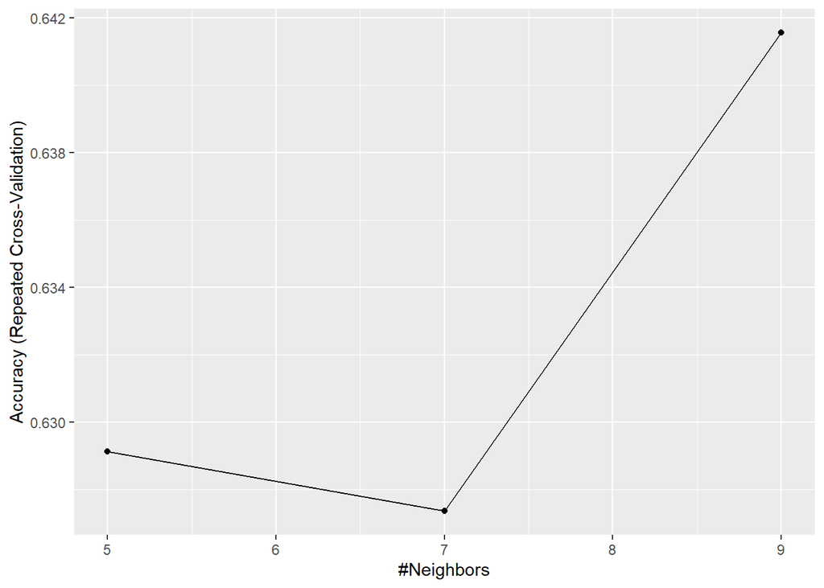

```r
for (i in c("knn", "ada", "gbm", "rf")) {
  assign(paste0(i,"_model"), train(form = formula_full,
                  data = heart_train,
                  method = i,
                  trControl = fitControl
                  )
  )
}

# plot the results
ggplot(knn_model)
```

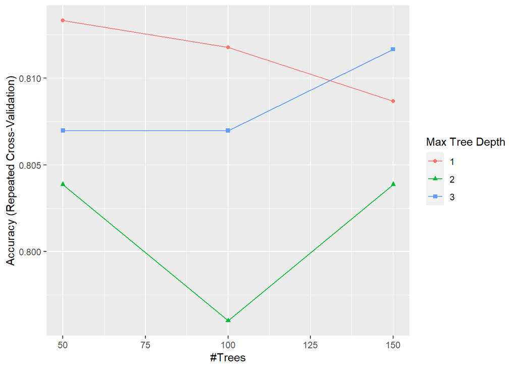

```r
ggplot(ada_model)
```

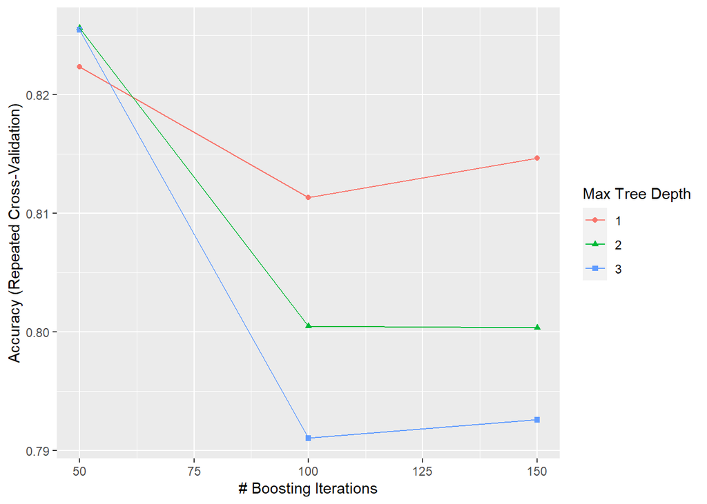

```r
ggplot(gbm_model)
```

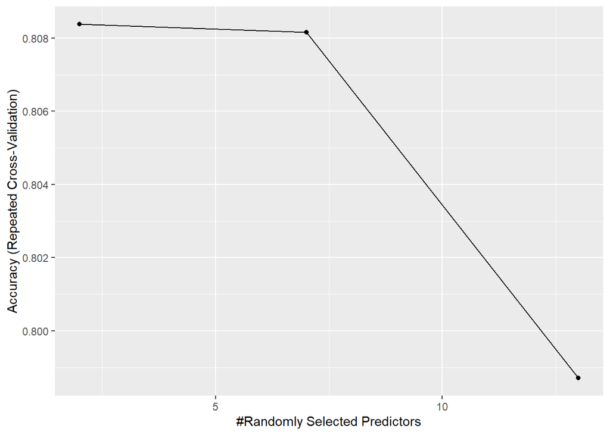

```r
ggplot(rf_model)
```

### Question 3 - Define gbm Grid

```r
grid_gbm <- expand.grid(
            interaction.depth = c(1,5,9),
            n.trees = (1:30)*50,
            shrinkage = 0.1,
            n.minobsinnode = 20
)
```

### Question 4 - train the gbm with the new parameters grid

```r
gbm_model2 <- train(form = formula_full,
                  data = heart_train,
                  method = "gbm",
                  trControl = fitControl,
                  tuneGrid = grid_gbm
                  )
```

### Question 5 -Plot the results side by side

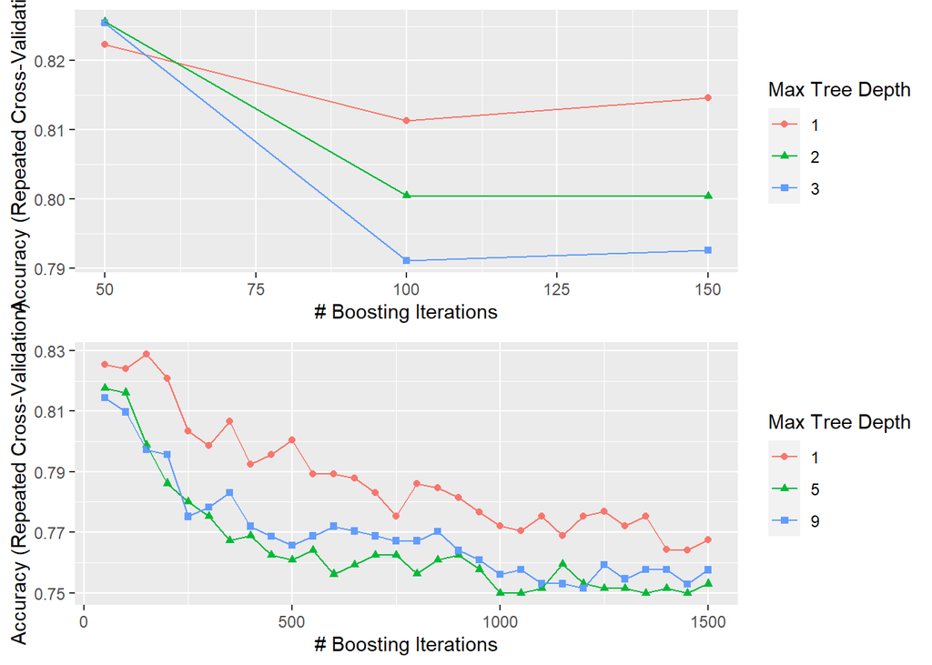

```r
gridExtra::grid.arrange(ggplot(gbm_model),ggplot(gbm_model2))
```

## Part 3 - Interpretability

### Question 1 - explain our models

```r
# Seperate the data
y <- as.numeric(as.character(heart_train$target))
x <- heart_train[, names(heart_train) != "target"]

knn_explain <- explain(knn_model,
                      label= "knn",
                      data = x,
                      y = y)
```

```
## Preparation of a new explainer is initiated
##   -> model label       :  knn
##   -> data              :  212  rows  13  cols
##   -> data              :  tibble converted into a data.frame
##   -> target variable   :  212  values
##   -> predict function  :  yhat.train  will be used (  default  )
##   -> predicted values  :  No value for predict function target column. (  default  )
##   -> model_info        :  package caret , ver. 6.0.94 , task classification (  default  )
##   -> predicted values  :  numerical, min =  0.1111111 , mean =  0.5660901 , max =  1
##   -> residual function :  difference between y and yhat (  default  )
##   -> residuals         :  numerical, min =  -0.8888889 , mean =  -5.24109e-05 , max =  0.8888889
##   A new explainer has been created!
```

```r
ada_explain <- explain(ada_model,
                      label= "ada",
                      data = x,
                      y = y)
```

```
## Preparation of a new explainer is initiated
##   -> model label       :  ada
##   -> data              :  212  rows  13  cols
##   -> data              :  tibble converted into a data.frame
##   -> target variable   :  212  values
##   -> predict function  :  yhat.train  will be used (  default  )
##   -> predicted values  :  No value for predict function target column. (  default  )
##   -> model_info        :  package caret , ver. 6.0.94 , task classification (  default  )
##   -> predicted values  :  numerical, min =  0.05645431 , mean =  0.5685384 , max =  0.9399581
##   -> residual function :  difference between y and yhat (  default  )
##   -> residuals         :  numerical, min =  -0.8962885 , mean =  -0.0025007 , max =  0.8375453
##   A new explainer has been created!
```

```r
gbm_explain <- explain(gbm_model2,
                      label= "gbm",
                      data = x,
                      y = y)
```

```
## Preparation of a new explainer is initiated
##   -> model label       :  gbm
##   -> data              :  212  rows  13  cols
##   -> data              :  tibble converted into a data.frame
##   -> target variable   :  212  values
##   -> predict function  :  yhat.train  will be used (  default  )
##   -> predicted values  :  No value for predict function target column. (  default  )
##   -> model_info        :  package caret , ver. 6.0.94 , task classification (  default  )
##   -> predicted values  :  numerical, min =  0.004117397 , mean =  0.5743637 , max =  0.9958408
##   -> residual function :  difference between y and yhat (  default  )
##   -> residuals         :  numerical, min =  -0.9543883 , mean =  -0.008325925 , max =  0.8806044
##   A new explainer has been created!
```

```r
rf_explain <- explain(rf_model,
                      label= "rf",
                      data = x,
                      y = y)
```

```
## Preparation of a new explainer is initiated
##   -> model label       :  rf
##   -> data              :  212  rows  13  cols
##   -> data              :  tibble converted into a data.frame
##   -> target variable   :  212  values
##   -> predict function  :  yhat.train  will be used (  default  )
##   -> predicted values  :  No value for predict function target column. (  default  )
##   -> model_info        :  package caret , ver. 6.0.94 , task classification (  default  )
##   -> predicted values  :  numerical, min =  0.002 , mean =  0.567283 , max =  1
##   -> residual function :  difference between y and yhat (  default  )
##   -> residuals         :  numerical, min =  -0.452 , mean =  -0.001245283 , max =  0.378
##   A new explainer has been created!
```

### Question 2 - model performance

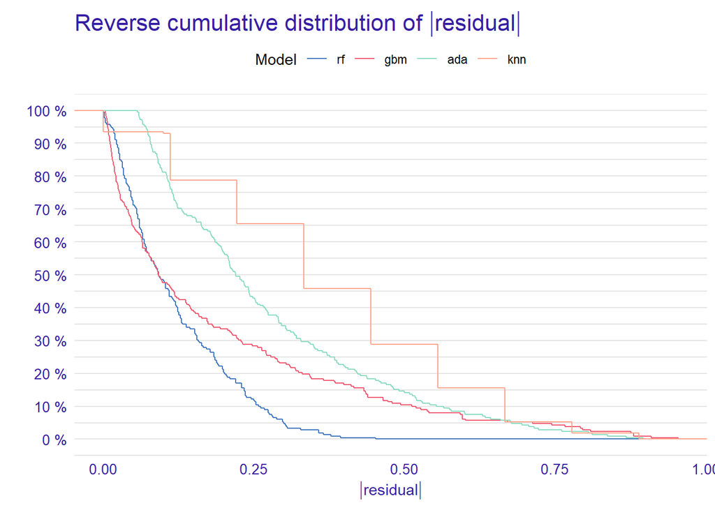

```r
# Loop through the models
for (model in c("knn", "ada", "gbm", "rf")) {

    explainer <- get(paste0(model, "_explain"))
    model_perf <- model_performance(explainer)
    assign(paste0(model, "_mp"), model_perf)
}

# Plot model performance line graph
plot(knn_mp, ada_mp, gbm_mp, rf_mp)
```

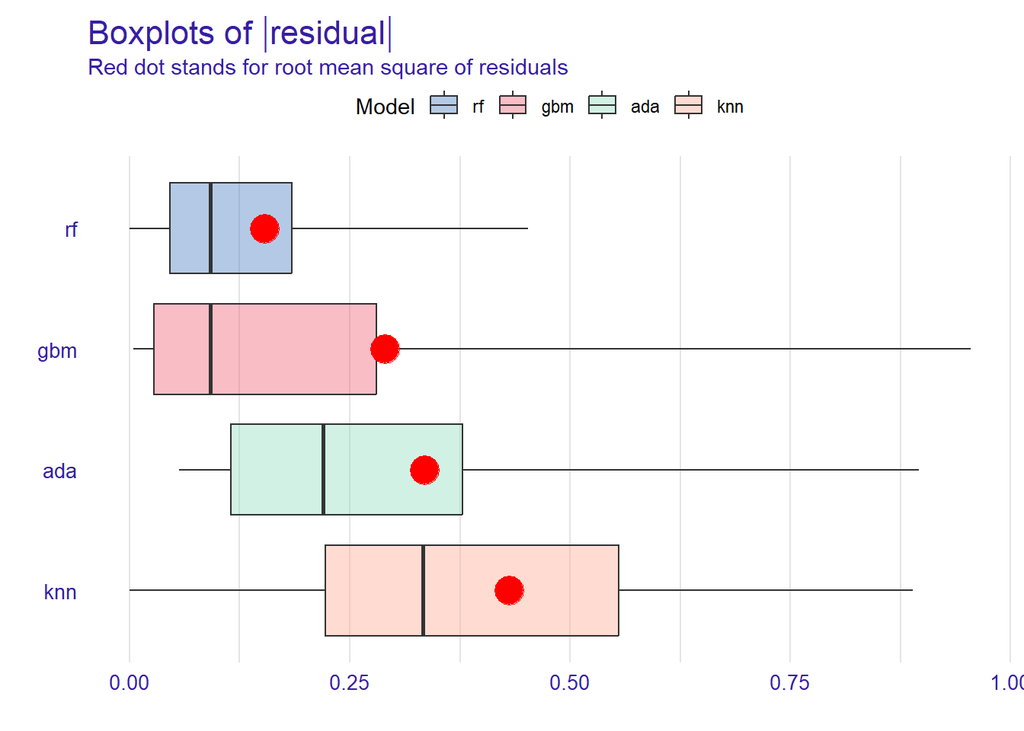

```r
# Plot model performance box plot
plot(knn_mp, ada_mp, gbm_mp, rf_mp, geom = "boxplot")
```

For my understanding, the model with the best performence should be the one in which : (1) we recognize the steepest decline - indicating a high proportion of residuals close to zero. (2) box plot with small and symatric box indicating for small spread of the residuals. Therefore, we can see from both of the plots that the random forest model gives us the best performance.

### Question 3 - variable importance

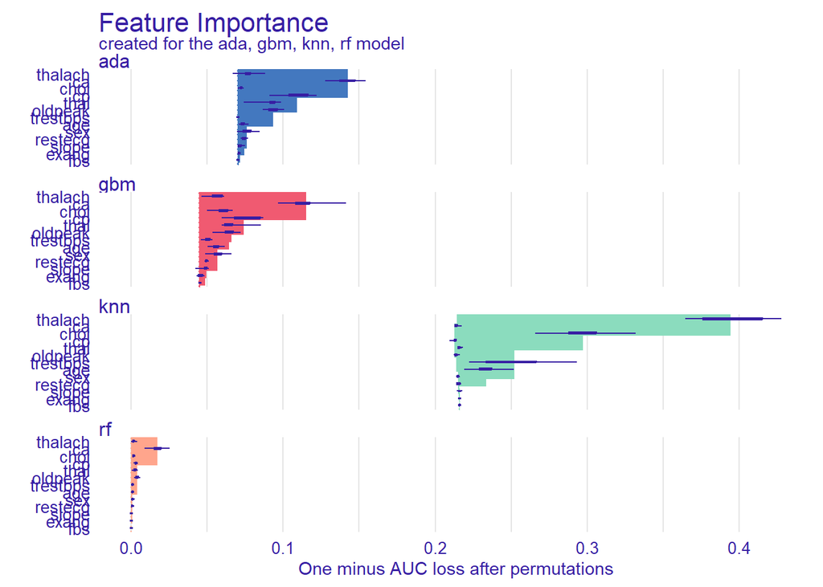

```r
# Loop through the models
for (model in c("knn", "ada", "gbm", "rf")) {
    explainer <- get(paste0(model, "_explain"))
    model_perf <- variable_importance(explainer)
    assign(paste0(model, "_vi"), model_perf)
}

# Plot variable importance
plot(knn_vi, ada_vi, gbm_vi, rf_vi)
```

### Question 4 - variable effect

```r
# Loop through the models
for (model in c("knn", "ada", "gbm", "rf")) {
    explainer <- get(paste0(model, "_explain"))
    model_perf <- variable_effect(explainer, variables = names(x))
    assign(paste0(model, "_ve"), model_perf)
}
```

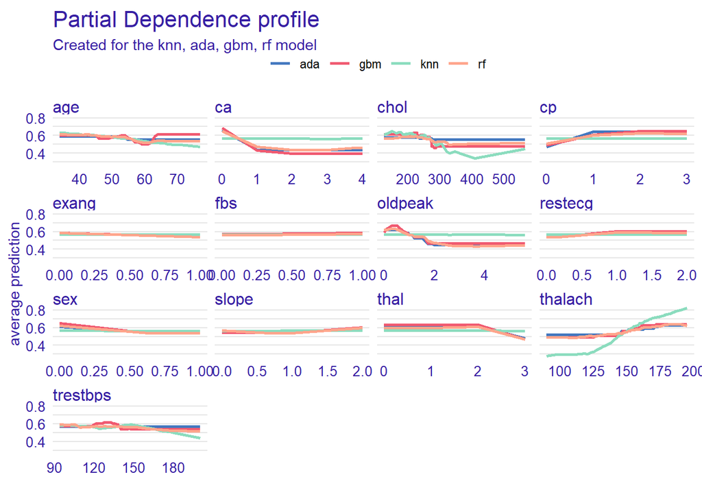

```r
# Plot variable importance
plot(knn_ve, ada_ve, gbm_ve, rf_ve)
```

From my understanding, if we notice a positive trend in any variable we can interpret it as if higher predictions (closer to 1) is correlated with higher values of this feature, and vice verse. Within this framework, the most significant trend can be seen in the “thalach” variable - the maximum heart rate acheived (based on online codebook). This is reasonable since high heart rate is common symptom for people proned to heart diseases.

### Question 5 - predicts part breakdown

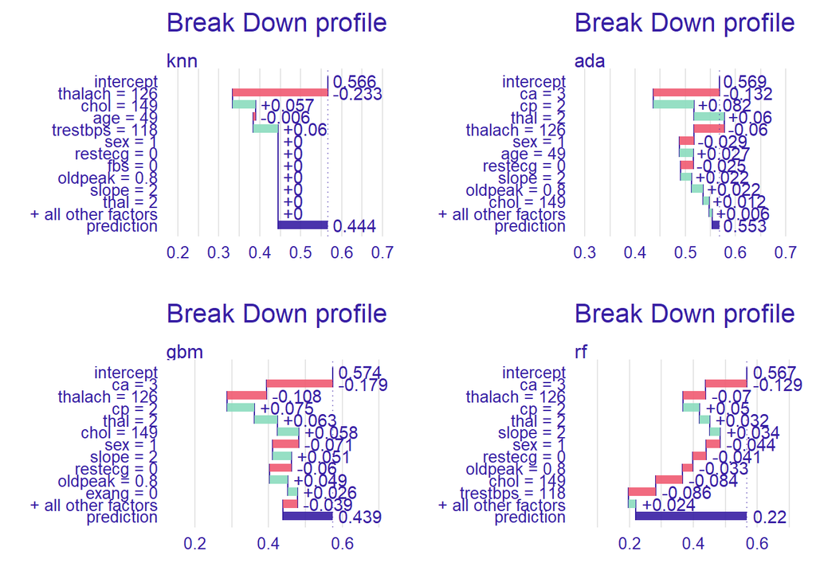

```r
first_row <- head(heart_train,1)

for (model in c("knn", "ada", "gbm", "rf")) {
    explainer <- get(paste0(model, "_explain"))
    model_perf <- predict_parts_break_down(explainer, first_row)
    assign(paste0(model, "_bd"), model_perf)
}

gridExtra::grid.arrange(plot(knn_bd),plot(ada_bd), plot(gbm_bd), plot(rf_bd))
```

### Question 6 - prediction

```r
for (i in c("knn", "ada", "gbm", "rf")) {
         assign(paste0(i,"_pred"),
         get(paste0(i,"_model")) %>%
           predict(newdata = heart_test) %>%
           as_tibble() %>%
           mutate(value = as.numeric(as.character(value))) %>%
           bind_cols(heart_test) %>%
           select(target, value) %>%
           rename("pred" = "value")
  )
}
```

### Question 7 - roc curves

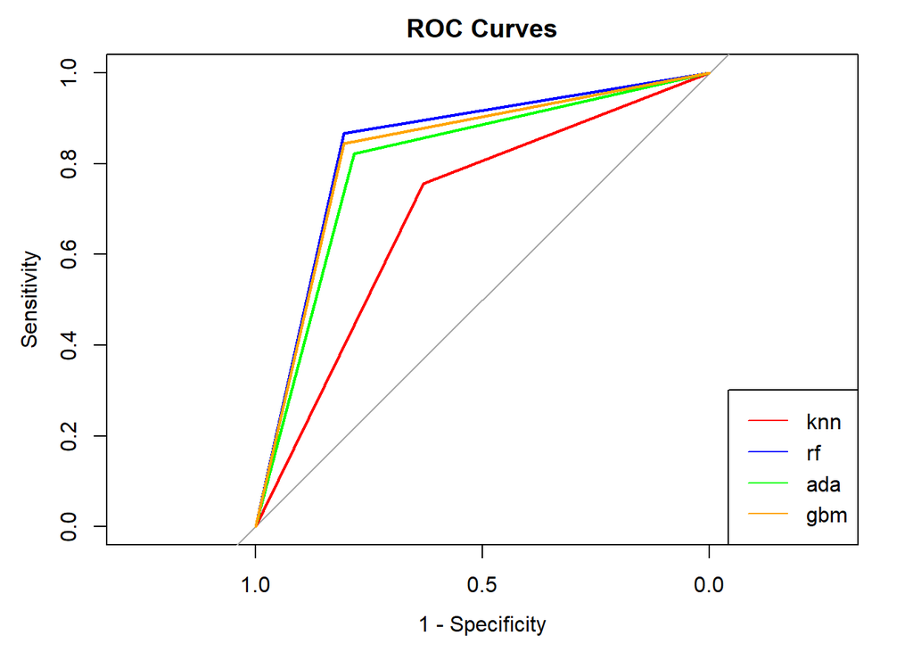

```r
#Create the curves
knn_roc <- roc(knn_pred$target, knn_pred$pred)
rf_roc <- roc(rf_pred$target, rf_pred$pred)
ada_roc <- roc(ada_pred$target, ada_pred$pred)
gbm_roc <- roc(gbm_pred$target, gbm_pred$pred)
#Plot all the curves together
# Plot the first ROC curve
plot(knn_roc, col = "red", main = "ROC Curves", xlim = c(1,0), ylim = c(0, 1), xlab = "1 - Specificity", ylab = "Sensitivity")

# Add the remaining ROC curves
lines(rf_roc, col = "blue")
lines(ada_roc, col = "green")
lines(gbm_roc, col = "orange")

# Add a legend
legend("bottomright", legend = c("knn", "rf", "ada", "gbm"), col = c("red", "blue", "green", "orange"), lwd = 1)
```

### Question 8 - auc of the boosting model

```r
# Compute the AUC
gbm_auc <- roc(gbm_pred$target, gbm_pred$pred)$auc
# Print the AUC
print(gbm_auc)
```

```
## Area under the curve: 0.8244
```